# Pembangkitan Data AR, MA dan ARMA

# White Noise

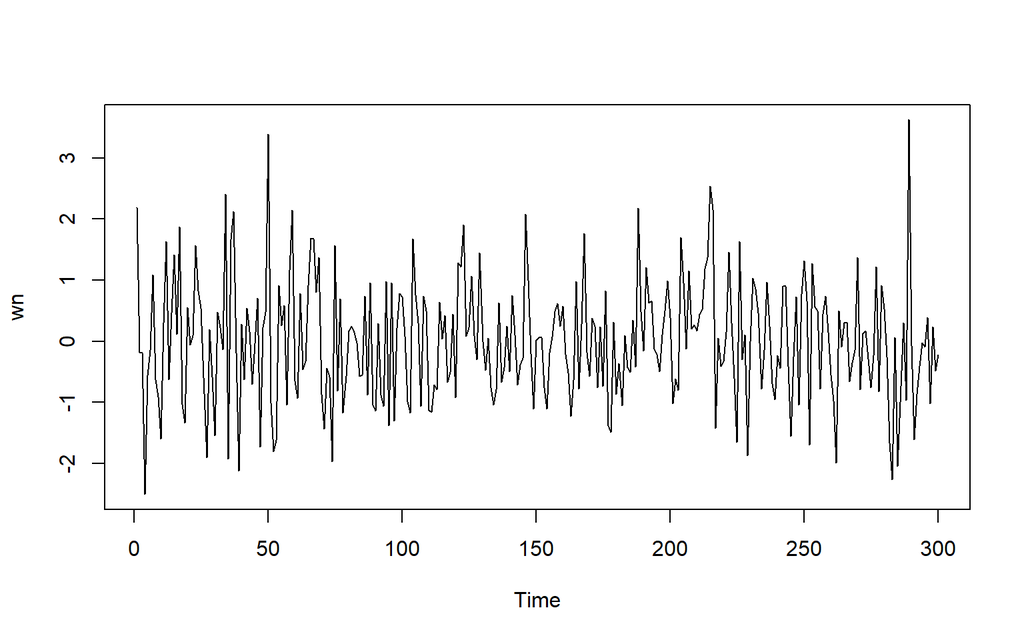

```r
set.seed(1001)
wn <- rnorm(300)
ts.plot(wn)
```

# MA(2)

Akan dibangkitkan suatu data dengan model MA(2) sebanyak 300 data yang memiliki nilai $\theta_1 = 0.4$ dan $\theta_2 = 0.6$.

$$y_t = e_t-0.4e_{t-1}-0.6e_{t-2}$$

```r
set.seed(1001)
ma <- c(1:300)
ma[1] <- wn[1]
ma[2] <- ma[2] - 0.4 * ma[1]
```

```r
for(i in 3:300){
   ma[i] <- wn[i] - 0.4 * wn[i - 1] - 0.6 * wn[i - 2]
}
ma
```

```
##   [1]  2.18864809  1.12454076 -1.42744520 -2.32589770  0.55646832  1.58328681
##   [7]  1.48331229 -0.97340874 -1.31318391 -0.85696290  1.48460606  2.46956260
##  [13] -1.45719023 -0.26473574  1.60550933 -0.73773779  0.97396365 -1.84426166
##  [19] -2.05131163  1.70920262  0.52115050 -0.21120904  1.56155240  0.14509078
##  [25] -0.72899874 -1.30790925 -1.98690183  1.31081115  0.48130097 -1.42859564
##  [31]  1.44597684  0.96494319 -0.51695053  2.32830464 -2.80433436  0.98561682
##  [37]  2.60985879 -2.03468961 -3.31957628  1.23847057  0.53709668  0.63035375
##  [43]  0.31257891 -1.09380527  0.15023556  1.14263996 -1.98343329  0.48792218
##  [49]  1.42146137  3.06242336 -2.64983176 -3.43187971 -0.29230290  2.64216653
##  [55]  0.86899108 -0.07060927 -1.43030093  1.22823469  2.30812121 -2.20139061
##  [61] -1.96077845  1.54556840 -0.22163469 -0.61288883  1.32620076  1.52009654
##  [67]  0.44814517 -0.88338775  0.04307891 -1.89045295 -1.90714000  0.65025554
##  [73]  0.45608594 -1.47461951  2.70117935 -0.25216857  0.08162506 -0.96527795
##  [79] -0.52288545  1.09775789  0.53024126 -0.05519445 -0.23190493 -0.64831318
##  [85] -0.30590255  1.30002170 -0.84076399  0.85894878 -0.90091539 -1.29709794
```

[output cut: 35 more lines]

Pembangkitan model MA(2) juga dapat dilakukan dengan menerapkan fungsi `arima.sim()`

```r
ma2 <- arima.sim(list(order=c(0,0,2), ma=c(0.4, 0.6)), n=300)
ma2
```

```
## Time Series:
## Start = 1
## End = 300
## Frequency = 1
##   [1]  1.056894643 -2.687174726 -1.671090990 -1.870405717  0.699691118
##   [6] -0.272478724 -0.501736857 -2.330463683 -0.879317033  0.799222262
##  [11]  0.213497130  1.199057934  1.233022346  0.958268198  2.765294819
##  [16] -0.216240023 -0.631957226 -0.600405931 -0.645292138  0.404412316
##  [21]  1.564348730  1.511373200  1.809127533  0.118020660 -1.814779991
##  [26] -0.923794729 -1.644901555 -1.661826023 -0.488352174 -0.506259944
##  [31]  0.241097574  2.493173407 -1.041254912  2.340267944  1.632859135
##  [36]  1.657928422 -0.924650004 -0.685276659 -1.788161526  0.461844161
##  [41] -0.001180833 -0.313927292 -0.226018623  0.267687201 -1.464772259
##  [46] -0.045163736 -0.470358573  3.708519551  0.629207091 -0.177563832
##  [51] -2.948455117 -0.819802805 -0.346518239  1.231798102 -0.652341695
```

[output cut: 49 more lines]

## Karakteristik MA(2)

### Plot Time Series

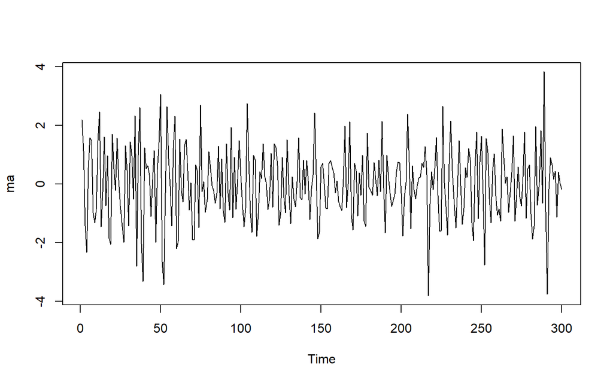

```r
ts.plot(ma)
```

Berdasarkan plot time series, terlihat bahwa data MA(2) yang dibangkitkan stasioner dalam rataan.

### Plot ACF

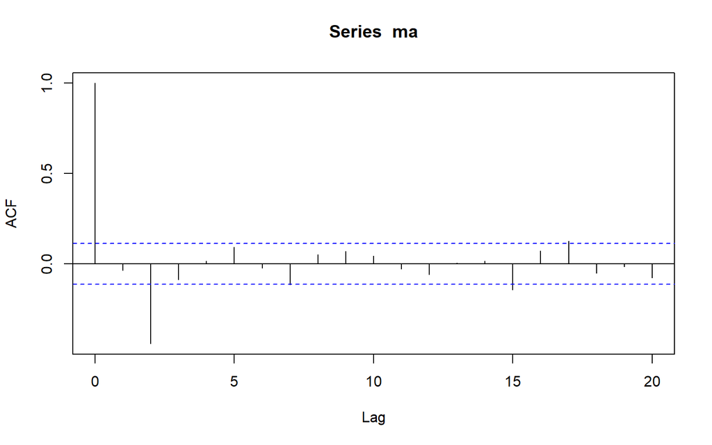

```r
hasil_acf <- acf(ma,lag.max = 20)
```

Berdasarkan plot AFC tersebut, terlihat bahwa plot ACF *cuts off* di lag kedua.

```r
hasil_acf
```

```
##
## Autocorrelations of series 'ma', by lag
##
##      0      1      2      3      4      5      6      7      8      9     10
##  1.000 -0.035 -0.441 -0.087  0.017  0.094 -0.022 -0.113  0.053  0.071  0.044
##     11     12     13     14     15     16     17     18     19     20
## -0.027 -0.058  0.006  0.016 -0.143  0.074  0.126 -0.051 -0.014 -0.075
```

### Plot PACF

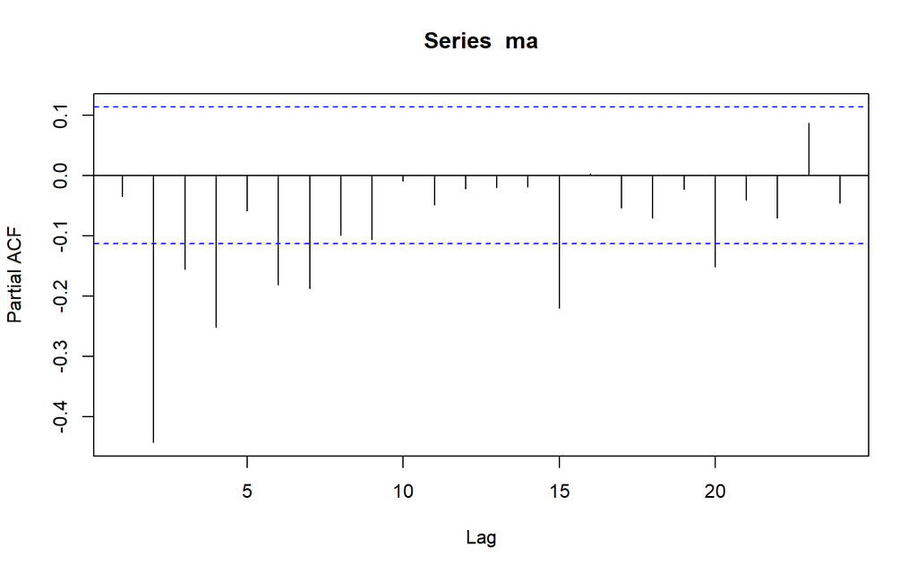

```r
pacf(ma)
```

Berdasarkan plot PACF tersebut, terlihat bahwa plot PACF cenderung *tails off* dan membentuk gelombang lembah karena nilai teta adalah positif.

### Plot EACF

```r
TSA::eacf(ma)
```

```
## AR/MA
##   0 1 2 3 4 5 6 7 8 9 10 11 12 13
## 0 o x o o o o o o o o o  o  o  o
## 1 o x x o o o o o o o o  o  o  o
## 2 x x x x o o o o o o o  o  o  o
## 3 x x o x x o o o o o o  o  o  o
## 4 x x o x o o o o o o o  o  o  o
## 5 x x x x x o o x o o o  o  o  o
## 6 x x x x x x o o o o o  o  o  o
## 7 x x x o x o o o x o o  o  o  o
```

Berdasarkan pola segitiga nol pada plot EACF, terlihat bahwa segitiga nol berada pada ordo AR(0) dan ordo MA(2) meskipun tidak sempurna namun hal ini bisa mendukung model MA(2).

### Scatterplot Antar Lag

#### Korelasi antara $Y_t$ dengan $Y_{t-1}$

```r
yt_ma <- ma[-1]
yt_ma
```

```
##   [1]  1.12454076 -1.42744520 -2.32589770  0.55646832  1.58328681  1.48331229
##   [7] -0.97340874 -1.31318391 -0.85696290  1.48460606  2.46956260 -1.45719023
##  [13] -0.26473574  1.60550933 -0.73773779  0.97396365 -1.84426166 -2.05131163
##  [19]  1.70920262  0.52115050 -0.21120904  1.56155240  0.14509078 -0.72899874
##  [25] -1.30790925 -1.98690183  1.31081115  0.48130097 -1.42859564  1.44597684
##  [31]  0.96494319 -0.51695053  2.32830464 -2.80433436  0.98561682  2.60985879
##  [37] -2.03468961 -3.31957628  1.23847057  0.53709668  0.63035375  0.31257891
##  [43] -1.09380527  0.15023556  1.14263996 -1.98343329  0.48792218  1.42146137
##  [49]  3.06242336 -2.64983176 -3.43187971 -0.29230290  2.64216653  0.86899108
##  [55] -0.07060927 -1.43030093  1.22823469  2.30812121 -2.20139061 -1.96077845
##  [61]  1.54556840 -0.22163469 -0.61288883  1.32620076  1.52009654  0.44814517
##  [67] -0.88338775  0.04307891 -1.89045295 -1.90714000  0.65025554  0.45608594
##  [73] -1.47461951  2.70117935 -0.25216857  0.08162506 -0.96527795 -0.52288545
##  [79]  1.09775789  0.53024126 -0.05519445 -0.23190493 -0.64831318 -0.30590255
##  [85]  1.30002170 -0.84076399  0.85894878 -0.90091539 -1.29709794  1.37183190
```

[output cut: 35 more lines]

```r
yt_1_ma <- ma[-300]
yt_1_ma
```

```
##   [1]  2.18864809  1.12454076 -1.42744520 -2.32589770  0.55646832  1.58328681
##   [7]  1.48331229 -0.97340874 -1.31318391 -0.85696290  1.48460606  2.46956260
##  [13] -1.45719023 -0.26473574  1.60550933 -0.73773779  0.97396365 -1.84426166
##  [19] -2.05131163  1.70920262  0.52115050 -0.21120904  1.56155240  0.14509078
##  [25] -0.72899874 -1.30790925 -1.98690183  1.31081115  0.48130097 -1.42859564
##  [31]  1.44597684  0.96494319 -0.51695053  2.32830464 -2.80433436  0.98561682
##  [37]  2.60985879 -2.03468961 -3.31957628  1.23847057  0.53709668  0.63035375
##  [43]  0.31257891 -1.09380527  0.15023556  1.14263996 -1.98343329  0.48792218
##  [49]  1.42146137  3.06242336 -2.64983176 -3.43187971 -0.29230290  2.64216653
##  [55]  0.86899108 -0.07060927 -1.43030093  1.22823469  2.30812121 -2.20139061
##  [61] -1.96077845  1.54556840 -0.22163469 -0.61288883  1.32620076  1.52009654
##  [67]  0.44814517 -0.88338775  0.04307891 -1.89045295 -1.90714000  0.65025554
##  [73]  0.45608594 -1.47461951  2.70117935 -0.25216857  0.08162506 -0.96527795
##  [79] -0.52288545  1.09775789  0.53024126 -0.05519445 -0.23190493 -0.64831318
##  [85] -0.30590255  1.30002170 -0.84076399  0.85894878 -0.90091539 -1.29709794
```

[output cut: 35 more lines]

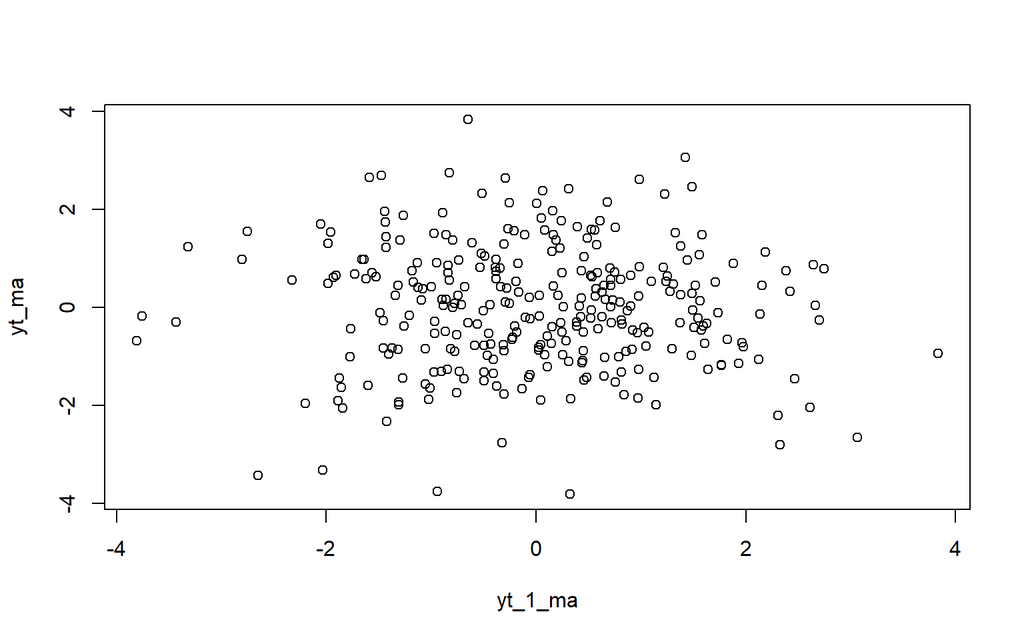

```r
plot(y=yt_ma,x=yt_1_ma)
```

Berdasarkan scatterplot tersebut, terlihat bahwa terdapat hubungan negatif yang sangat lemah cenderung tidak berpola $Y_t$ dengan $Y_{t-1}$. Hal tersebut dibuktikan dengan nilai korelasi yang negatif dan nilai yang kecil:

```r
cor(yt_ma,yt_1_ma)
```

```
## [1] -0.03521767
```

Korelasi antara $Y_t$ dengan $Y_{t-1}$ dari hasil simulasi cukup dekat dengan teori, meskipun sedikit lebih kecil yang jika berdasarkan teori:

$$\rho_1=\frac{-\theta_1+\theta_1\theta_2}{1+\theta_1^2+\theta_2^2}=\frac{-0.4+0.4\times0.6}{1+0.4^2+0.6^2}=-0.105$$

#### Korelasi antara $Y_t$ dengan $Y_{t-2}$

```r
yt_ma2 <- ma[-c(1,2)]
yt_ma2
```

```
##   [1] -1.42744520 -2.32589770  0.55646832  1.58328681  1.48331229 -0.97340874
##   [7] -1.31318391 -0.85696290  1.48460606  2.46956260 -1.45719023 -0.26473574
##  [13]  1.60550933 -0.73773779  0.97396365 -1.84426166 -2.05131163  1.70920262
##  [19]  0.52115050 -0.21120904  1.56155240  0.14509078 -0.72899874 -1.30790925
##  [25] -1.98690183  1.31081115  0.48130097 -1.42859564  1.44597684  0.96494319
##  [31] -0.51695053  2.32830464 -2.80433436  0.98561682  2.60985879 -2.03468961
##  [37] -3.31957628  1.23847057  0.53709668  0.63035375  0.31257891 -1.09380527
##  [43]  0.15023556  1.14263996 -1.98343329  0.48792218  1.42146137  3.06242336
##  [49] -2.64983176 -3.43187971 -0.29230290  2.64216653  0.86899108 -0.07060927
##  [55] -1.43030093  1.22823469  2.30812121 -2.20139061 -1.96077845  1.54556840
##  [61] -0.22163469 -0.61288883  1.32620076  1.52009654  0.44814517 -0.88338775
##  [67]  0.04307891 -1.89045295 -1.90714000  0.65025554  0.45608594 -1.47461951
##  [73]  2.70117935 -0.25216857  0.08162506 -0.96527795 -0.52288545  1.09775789
##  [79]  0.53024126 -0.05519445 -0.23190493 -0.64831318 -0.30590255  1.30002170
##  [85] -0.84076399  0.85894878 -0.90091539 -1.29709794  1.37183190 -0.30713937
```

[output cut: 35 more lines]

```r
yt_2_ma <- ma[-c(299,300)]
yt_2_ma
```

```
##   [1]  2.18864809  1.12454076 -1.42744520 -2.32589770  0.55646832  1.58328681
##   [7]  1.48331229 -0.97340874 -1.31318391 -0.85696290  1.48460606  2.46956260
##  [13] -1.45719023 -0.26473574  1.60550933 -0.73773779  0.97396365 -1.84426166
##  [19] -2.05131163  1.70920262  0.52115050 -0.21120904  1.56155240  0.14509078
##  [25] -0.72899874 -1.30790925 -1.98690183  1.31081115  0.48130097 -1.42859564
##  [31]  1.44597684  0.96494319 -0.51695053  2.32830464 -2.80433436  0.98561682
##  [37]  2.60985879 -2.03468961 -3.31957628  1.23847057  0.53709668  0.63035375
##  [43]  0.31257891 -1.09380527  0.15023556  1.14263996 -1.98343329  0.48792218
##  [49]  1.42146137  3.06242336 -2.64983176 -3.43187971 -0.29230290  2.64216653
##  [55]  0.86899108 -0.07060927 -1.43030093  1.22823469  2.30812121 -2.20139061
##  [61] -1.96077845  1.54556840 -0.22163469 -0.61288883  1.32620076  1.52009654
##  [67]  0.44814517 -0.88338775  0.04307891 -1.89045295 -1.90714000  0.65025554
##  [73]  0.45608594 -1.47461951  2.70117935 -0.25216857  0.08162506 -0.96527795
##  [79] -0.52288545  1.09775789  0.53024126 -0.05519445 -0.23190493 -0.64831318
##  [85] -0.30590255  1.30002170 -0.84076399  0.85894878 -0.90091539 -1.29709794
```

[output cut: 35 more lines]

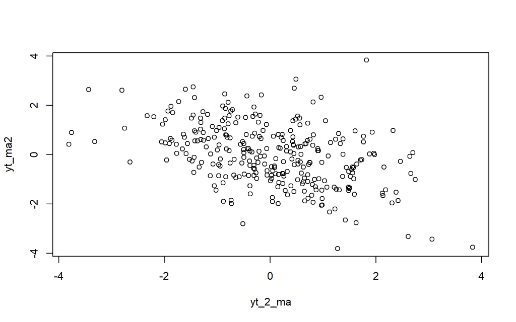

```r
plot(y=yt_ma2,x=yt_2_ma)
```

Berdasarkan scatterplot tersebut, terlihat bahwa terdapat hubungan negatif antara $Y_t$ dengan $Y_{t-2}$.

```r
cor(yt_ma2,yt_2_ma)
```

```
## [1] -0.4436381
```

Korelasi antara $Y_t$ dengan $Y_{t-2}$ dari hasil simulasi juga cukup dekat dengan teori, meskipun lebih besar dengan perhitungan teoritis yaitu:

$$\rho_2=\frac{-\theta_2}{1+\theta_1^2+\theta_2^2}=\frac{-0.6}{1+0.4^2+0.6^2}=-0.394$$

#### Korelasi antara $Y_t$ dengan $Y_{t-3}$

```r
yt_ma3 <- ma[-c(1,2,3)]
yt_ma3
```

```
##   [1] -2.32589770  0.55646832  1.58328681  1.48331229 -0.97340874 -1.31318391
##   [7] -0.85696290  1.48460606  2.46956260 -1.45719023 -0.26473574  1.60550933
##  [13] -0.73773779  0.97396365 -1.84426166 -2.05131163  1.70920262  0.52115050
##  [19] -0.21120904  1.56155240  0.14509078 -0.72899874 -1.30790925 -1.98690183
##  [25]  1.31081115  0.48130097 -1.42859564  1.44597684  0.96494319 -0.51695053
##  [31]  2.32830464 -2.80433436  0.98561682  2.60985879 -2.03468961 -3.31957628
##  [37]  1.23847057  0.53709668  0.63035375  0.31257891 -1.09380527  0.15023556
##  [43]  1.14263996 -1.98343329  0.48792218  1.42146137  3.06242336 -2.64983176
##  [49] -3.43187971 -0.29230290  2.64216653  0.86899108 -0.07060927 -1.43030093
##  [55]  1.22823469  2.30812121 -2.20139061 -1.96077845  1.54556840 -0.22163469
##  [61] -0.61288883  1.32620076  1.52009654  0.44814517 -0.88338775  0.04307891
##  [67] -1.89045295 -1.90714000  0.65025554  0.45608594 -1.47461951  2.70117935
##  [73] -0.25216857  0.08162506 -0.96527795 -0.52288545  1.09775789  0.53024126
##  [79] -0.05519445 -0.23190493 -0.64831318 -0.30590255  1.30002170 -0.84076399
##  [85]  0.85894878 -0.90091539 -1.29709794  1.37183190 -0.30713937 -0.88751786
```

[output cut: 35 more lines]

```r
yt_3_ma <- ma[-c(298, 299,300)]
yt_3_ma
```

```
##   [1]  2.18864809  1.12454076 -1.42744520 -2.32589770  0.55646832  1.58328681
##   [7]  1.48331229 -0.97340874 -1.31318391 -0.85696290  1.48460606  2.46956260
##  [13] -1.45719023 -0.26473574  1.60550933 -0.73773779  0.97396365 -1.84426166
##  [19] -2.05131163  1.70920262  0.52115050 -0.21120904  1.56155240  0.14509078
##  [25] -0.72899874 -1.30790925 -1.98690183  1.31081115  0.48130097 -1.42859564
##  [31]  1.44597684  0.96494319 -0.51695053  2.32830464 -2.80433436  0.98561682
##  [37]  2.60985879 -2.03468961 -3.31957628  1.23847057  0.53709668  0.63035375
##  [43]  0.31257891 -1.09380527  0.15023556  1.14263996 -1.98343329  0.48792218
##  [49]  1.42146137  3.06242336 -2.64983176 -3.43187971 -0.29230290  2.64216653
##  [55]  0.86899108 -0.07060927 -1.43030093  1.22823469  2.30812121 -2.20139061
##  [61] -1.96077845  1.54556840 -0.22163469 -0.61288883  1.32620076  1.52009654
##  [67]  0.44814517 -0.88338775  0.04307891 -1.89045295 -1.90714000  0.65025554
##  [73]  0.45608594 -1.47461951  2.70117935 -0.25216857  0.08162506 -0.96527795
##  [79] -0.52288545  1.09775789  0.53024126 -0.05519445 -0.23190493 -0.64831318
##  [85] -0.30590255  1.30002170 -0.84076399  0.85894878 -0.90091539 -1.29709794
```

[output cut: 35 more lines]

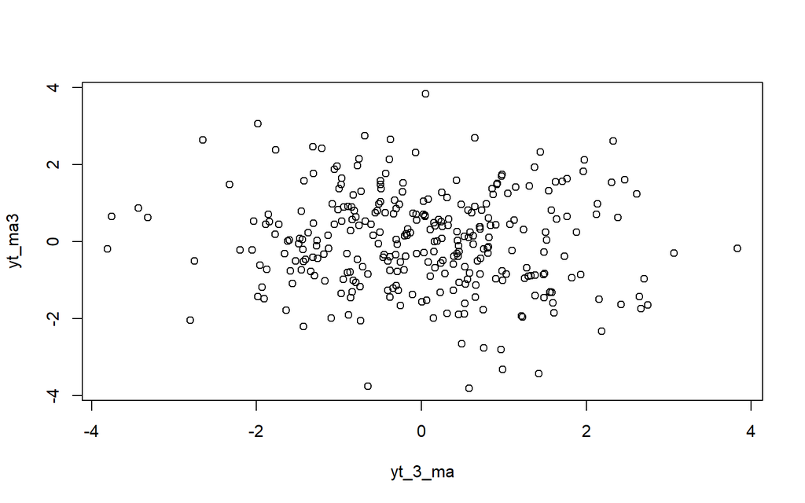

```r
plot(y=yt_ma3,x=yt_3_ma)
```

Berdasarkan scatterplot tersebut, terlihat bahwa $Y_t$ dan $Y_{t-3}$ sudah menunjukkan pola yang tidak beraturan atau bisa disebut tidak berpola.

```r
cor(yt_ma3,yt_3_ma)
```

```
## [1] -0.08808104
```

Korelasi antara $Y_t$ dengan $Y_{t-3}$ dari hasil simulasi cukup mendekati nilai teoritis yang menyatakan bahwa $\rho_k=0$ untuk k>q.

### Kesimpulan

Berdasarkan analisis, data bangkitan menunjukkan karakteristik yang sangat konsisten dengan model teoretis MA(2). Plot ACF cut off dengan jelas setelah lag 2, yang merupakan penanda utama model MA(2).

Konsistensi ini juga didukung oleh perbandingan nilai autokorelasi, di mana nilai empiris dari data bangkitan cukup mendekati nilai teoretisnya:

ρ₁: –0.035 vs –0.105

ρ₂: –0.44 vs –0.395

ρ₃: –0.088 vs 0

Meskipun tidak identik, perbedaan yang ada dapat diatribusikan pada variabilitas acak yang wajar terjadi pada simulasi data. Nilai ρ₃ yang kecil dan kemungkinan tidak signifikan secara statistik tetap sejalan dengan teori model MA(2) yang autokorelasinya menjadi nol setelah lag 2. Dengan demikian, dapat disimpulkan bahwa simulasi data telah berhasil merepresentasikan struktur dan pola korelasi dari sebuah proses MA(2) secara memadai.

# AR(2)

Dalam kasus ini, akan dibangkitkan suatu data dengan model AR(2) sebanyak 300 data yang memiliki nilai $\phi_1 = 0.5$ dan $\phi_2 = 0.2$. Rumusan model tersebut adalah sebagai berikut

$$Y_t = e_t+0.5Y_{t-1}+0.2Y_{t-2}$$

```r
set.seed(2045)
ar <- c(1:300)
ar[1] <- wn[1]
ar[2] <- wn[2] + 0.5 * ar[1]
```

```r
for (i in 3:300) {
  ar[i] <- wn[i] + 0.5 * ar[i-1] + 0.2 * ar[i-2]
}
ar
```

```
##   [1]  2.188648093  0.916776712  0.710842695 -1.967759524 -1.399022560
##   [6] -1.236622638  0.193385871 -0.773575325 -1.255570873 -2.376213791
##  [11] -1.136576557  0.590861394 -0.553731165  0.308467792  1.462753501
##  [16]  0.903335515  2.613847691  0.457340108 -0.590194838  0.350768948
##  [21] -0.004725311  0.164392770  1.644201889  1.683211490  1.710510519
##  [26]  0.596953264 -1.260262175 -0.317232223 -0.992468839 -2.104891697
##  [31] -0.772127281 -0.577700359 -0.581202111  2.004597897 -1.036736110
##  [36]  1.545493908  2.686758695  1.464097536 -0.852712637  0.143060143
##  [41] -0.724544878  0.212438546  0.117009335 -0.602873904 -0.315926619
##  [46]  0.426625493 -1.573975350 -0.480283353 -0.079385346  3.249722113
##  [51]  0.598671655 -0.855441523 -1.928365438 -0.224089162 -0.236481248
##  [56]  0.417535960 -0.879849584  0.803645216  2.373206244  0.700920671
##  [61] -0.105829329  0.872618607 -0.050910141 -0.179032127  0.815630213
##  [66]  2.061376078  2.866903189  2.645195145  3.262697915  1.296303916
##  [71] -0.132050267 -0.248055978 -0.730513839 -2.386292920  0.225314726
```

[output cut: 45 more lines]

Pembangkitan model AR(2) juga dapat dilakukan dengan menerapkan fungsi `arima.sim()`

```r
ar2 <- arima.sim(list(order=c(2,0,0), ar=c(0.5,0.2)), n=300)
ar2
```

```
## Time Series:
## Start = 1
## End = 300
## Frequency = 1
##   [1] -2.548034118 -2.023349904 -1.529433064 -1.252651144 -0.098440109
##   [6] -1.217853608 -2.068596771 -2.612837741 -1.605933932 -1.206627806
##  [11]  0.100610917  0.296918298  2.213274198  1.304115512  1.818780021
##  [16]  0.718679101 -0.042559721  1.131775877 -0.063901745  0.110668328
##  [21] -0.536173487 -0.464510283 -1.754009054 -0.179974681 -0.148919665
##  [26] -0.119639560  0.349312868  1.222631538 -0.474740392 -1.350357040
##  [31] -0.436715343 -1.637800528 -0.024276080 -0.397876073  0.430292263
##  [36] -1.176418589 -0.278187873  0.528451401  0.396331223  0.756909322
##  [41]  1.294856293  1.155846495 -0.822637989 -1.278652928 -1.693699786
##  [46] -1.648627168 -0.775305758 -1.773598336 -1.557341726 -0.767990768
##  [51] -1.485018114 -1.652698099 -2.548366279 -0.627212755 -2.371863661
```

[output cut: 49 more lines]

## Karakteristik AR(2)

### Plot Time Series

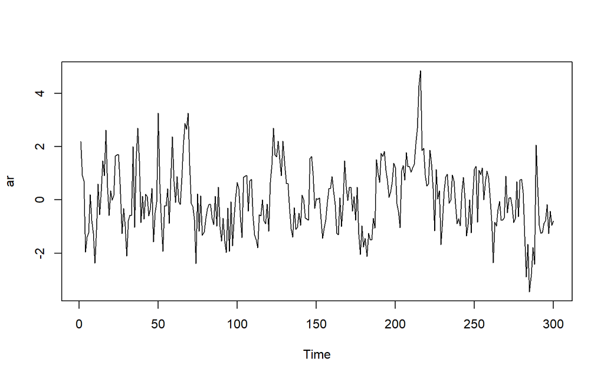

```r
ts.plot(ar)
```

Berdasarkan plot time series tersebut terlihat bahwa data cenderung stasioner pada rataan.

### Plot ACF

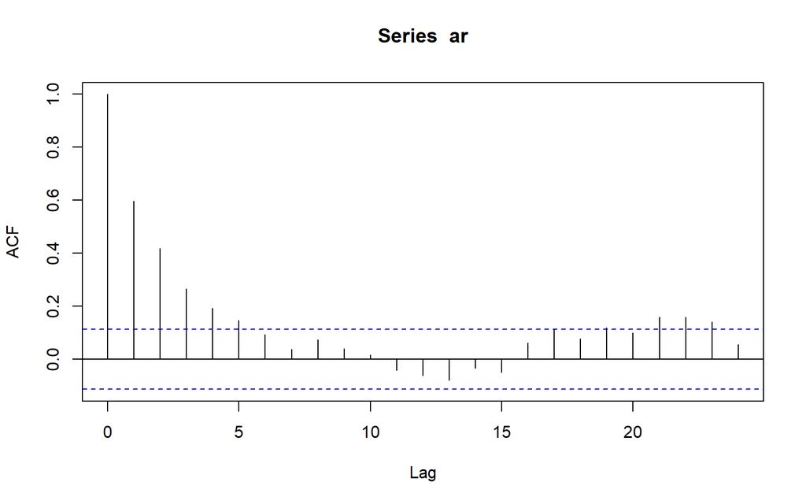

```r
acf(ar)
```

Berdasarkan plot ACF tersebut terlihat bahwa plot ACF cenderung *tails off* sesuai dengan teori bahwa model AR akan tails off pada plot ACF.

### Plot PACF

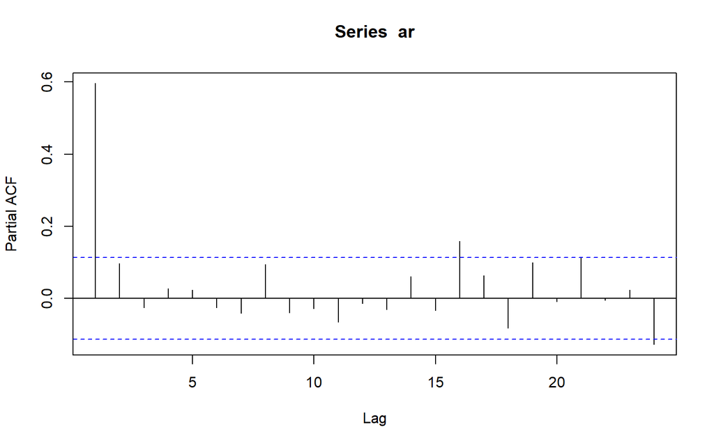

```r
pacf(ar)
```

Berdasarkan plot PACF tersebut, terlihat bahwa plot PACF *cuts off* pada lag pertama hal ini menandakan data mungin cocok untuk AR(1).

### Plot EACF

```r
TSA::eacf(ar)
```

```
## AR/MA
##   0 1 2 3 4 5 6 7 8 9 10 11 12 13
## 0 x x x x x o o o o o o  o  o  o
## 1 x o o o o o o o o o o  o  o  o
## 2 x o o o o o o o o o o  o  o  o
## 3 x x o o o o o o o o o  o  o  o
## 4 x x o o o o o o o o o  o  o  o
## 5 x x o o o o o o o o o  o  o  o
## 6 x x x x o o o o o o o  o  o  o
## 7 x x o o o o o o o o o  o  o  o
```

Berdasarkan pola segitiga nol pada plot EACF, terlihat bahwa segitiga nol berada pada ordo AR(1) dan ordo MA(1).

### Scatterplot Antar Lag

#### Korelasi antara $Y_t$ dengan $Y_{t-1}$

```r
yt_ar <- ar[-1]
yt_ar
```

```
##   [1]  0.916776712  0.710842695 -1.967759524 -1.399022560 -1.236622638
##   [6]  0.193385871 -0.773575325 -1.255570873 -2.376213791 -1.136576557
##  [11]  0.590861394 -0.553731165  0.308467792  1.462753501  0.903335515
##  [16]  2.613847691  0.457340108 -0.590194838  0.350768948 -0.004725311
##  [21]  0.164392770  1.644201889  1.683211490  1.710510519  0.596953264
##  [26] -1.260262175 -0.317232223 -0.992468839 -2.104891697 -0.772127281
##  [31] -0.577700359 -0.581202111  2.004597897 -1.036736110  1.545493908
##  [36]  2.686758695  1.464097536 -0.852712637  0.143060143 -0.724544878
##  [41]  0.212438546  0.117009335 -0.602873904 -0.315926619  0.426625493
##  [46] -1.573975350 -0.480283353 -0.079385346  3.249722113  0.598671655
##  [51] -0.855441523 -1.928365438 -0.224089162 -0.236481248  0.417535960
##  [56] -0.879849584  0.803645216  2.373206244  0.700920671 -0.105829329
##  [61]  0.872618607 -0.050910141 -0.179032127  0.815630213  2.061376078
##  [66]  2.866903189  2.645195145  3.262697915  1.296303916 -0.132050267
##  [71] -0.248055978 -0.730513839 -2.386292920  0.225314726 -1.173799088
```

[output cut: 45 more lines]

```r
yt_1_ar <- ar[-300]
yt_1_ar
```

```
##   [1]  2.188648093  0.916776712  0.710842695 -1.967759524 -1.399022560
##   [6] -1.236622638  0.193385871 -0.773575325 -1.255570873 -2.376213791
##  [11] -1.136576557  0.590861394 -0.553731165  0.308467792  1.462753501
##  [16]  0.903335515  2.613847691  0.457340108 -0.590194838  0.350768948
##  [21] -0.004725311  0.164392770  1.644201889  1.683211490  1.710510519
##  [26]  0.596953264 -1.260262175 -0.317232223 -0.992468839 -2.104891697
##  [31] -0.772127281 -0.577700359 -0.581202111  2.004597897 -1.036736110
##  [36]  1.545493908  2.686758695  1.464097536 -0.852712637  0.143060143
##  [41] -0.724544878  0.212438546  0.117009335 -0.602873904 -0.315926619
##  [46]  0.426625493 -1.573975350 -0.480283353 -0.079385346  3.249722113
##  [51]  0.598671655 -0.855441523 -1.928365438 -0.224089162 -0.236481248
##  [56]  0.417535960 -0.879849584  0.803645216  2.373206244  0.700920671
##  [61] -0.105829329  0.872618607 -0.050910141 -0.179032127  0.815630213
##  [66]  2.061376078  2.866903189  2.645195145  3.262697915  1.296303916
##  [71] -0.132050267 -0.248055978 -0.730513839 -2.386292920  0.225314726
```

[output cut: 45 more lines]

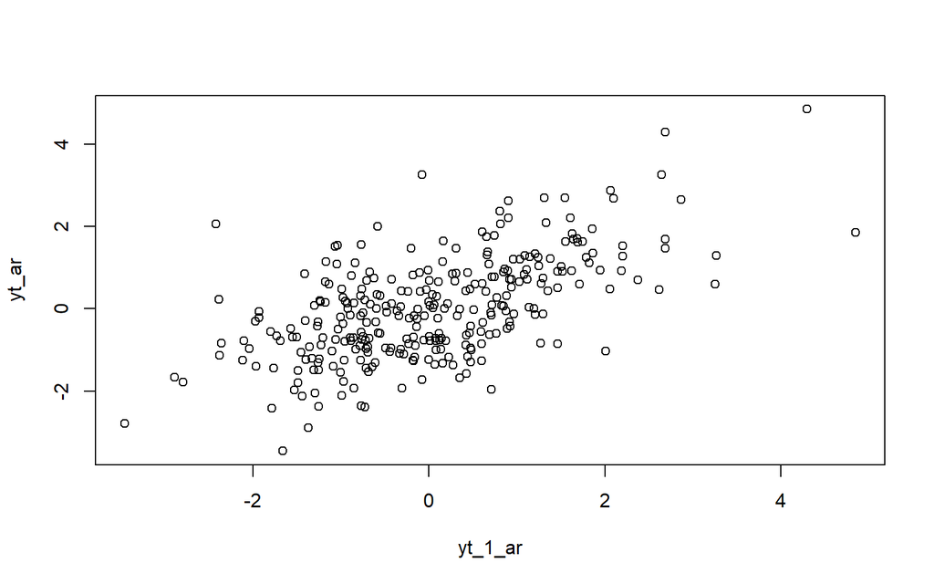

```r
plot(y=yt_ar,x=yt_1_ar)
```

Berdasarkan scatterplot tersebut, terlihat bahwa terdapat hubungan positif antara $Y_t$ dengan $Y_{t-1}$.

```r
cor(yt_ar,yt_1_ar)
```

```
## [1] 0.5996632
```

Korelasi antara $Y_t$ dengan $Y_{t-1}$ dari hasil simulasi sedikit mendekati perhitungan teoritis yaitu

$$\rho_1=\frac{\phi_1}{1-\phi_2}=\frac{0.5}{1-0.2}=0.625$$

#### Korelasi antara $Y_t$ dengan $Y_{t-2}$

```r
yt_ar2 <- ar[-c(1,2)]
yt_ar2
```

```
##   [1]  0.710842695 -1.967759524 -1.399022560 -1.236622638  0.193385871
##   [6] -0.773575325 -1.255570873 -2.376213791 -1.136576557  0.590861394
##  [11] -0.553731165  0.308467792  1.462753501  0.903335515  2.613847691
##  [16]  0.457340108 -0.590194838  0.350768948 -0.004725311  0.164392770
##  [21]  1.644201889  1.683211490  1.710510519  0.596953264 -1.260262175
##  [26] -0.317232223 -0.992468839 -2.104891697 -0.772127281 -0.577700359
##  [31] -0.581202111  2.004597897 -1.036736110  1.545493908  2.686758695
##  [36]  1.464097536 -0.852712637  0.143060143 -0.724544878  0.212438546
##  [41]  0.117009335 -0.602873904 -0.315926619  0.426625493 -1.573975350
##  [46] -0.480283353 -0.079385346  3.249722113  0.598671655 -0.855441523
##  [51] -1.928365438 -0.224089162 -0.236481248  0.417535960 -0.879849584
##  [56]  0.803645216  2.373206244  0.700920671 -0.105829329  0.872618607
##  [61] -0.050910141 -0.179032127  0.815630213  2.061376078  2.866903189
##  [66]  2.645195145  3.262697915  1.296303916 -0.132050267 -0.248055978
##  [71] -0.730513839 -2.386292920  0.225314726 -1.173799088  0.154847686
```

[output cut: 45 more lines]

```r
yt_2_ar <- ar[-c(299,300)]
yt_2_ar
```

```
##   [1]  2.188648093  0.916776712  0.710842695 -1.967759524 -1.399022560
##   [6] -1.236622638  0.193385871 -0.773575325 -1.255570873 -2.376213791
##  [11] -1.136576557  0.590861394 -0.553731165  0.308467792  1.462753501
##  [16]  0.903335515  2.613847691  0.457340108 -0.590194838  0.350768948
##  [21] -0.004725311  0.164392770  1.644201889  1.683211490  1.710510519
##  [26]  0.596953264 -1.260262175 -0.317232223 -0.992468839 -2.104891697
##  [31] -0.772127281 -0.577700359 -0.581202111  2.004597897 -1.036736110
##  [36]  1.545493908  2.686758695  1.464097536 -0.852712637  0.143060143
##  [41] -0.724544878  0.212438546  0.117009335 -0.602873904 -0.315926619
##  [46]  0.426625493 -1.573975350 -0.480283353 -0.079385346  3.249722113
##  [51]  0.598671655 -0.855441523 -1.928365438 -0.224089162 -0.236481248
##  [56]  0.417535960 -0.879849584  0.803645216  2.373206244  0.700920671
##  [61] -0.105829329  0.872618607 -0.050910141 -0.179032127  0.815630213
##  [66]  2.061376078  2.866903189  2.645195145  3.262697915  1.296303916
##  [71] -0.132050267 -0.248055978 -0.730513839 -2.386292920  0.225314726
```

[output cut: 45 more lines]

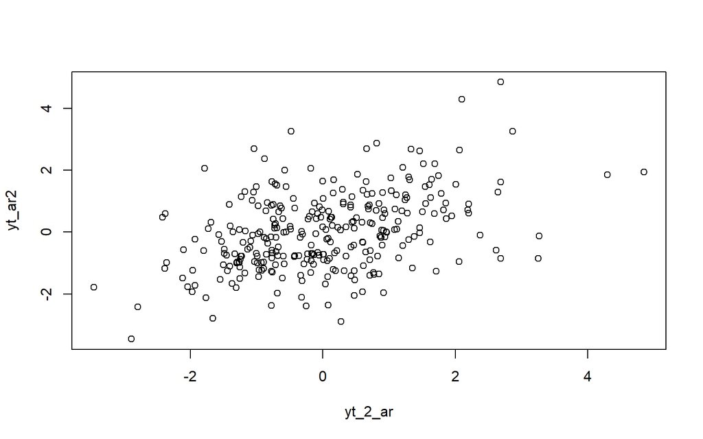

```r
plot(y=yt_ar2,x=yt_2_ar)
```

Berdasarkan scatterplot tersebut, terlihat bahwa terdapat hubungan positif antara $Y_t$ dengan $Y_{t-2}$.

```r
cor(yt_ar2,yt_2_ar)
```

```
## [1] 0.4212025
```

Korelasi antara $Y_t$ dengan $Y_{t-2}$ dari hasil simulasi sedikit mendekati perhitungan teoritis yaitu:

$$\rho_2=\phi_1\rho_{k-1}+\phi_2\rho_{k-2}=\frac{\phi_2(1-\phi_2)+\phi_1^2}{1-\phi_2}=\frac{0.2(1-0.2)+0.5^2}{1-0.2}=0.5125$$

#### Korelasi antara $Y_t$ dengan $Y_{t-3}$

```r
yt_ar3 <- ar[-c(1,2,3)]
yt_ar3
```

```
##   [1] -1.967759524 -1.399022560 -1.236622638  0.193385871 -0.773575325
##   [6] -1.255570873 -2.376213791 -1.136576557  0.590861394 -0.553731165
##  [11]  0.308467792  1.462753501  0.903335515  2.613847691  0.457340108
##  [16] -0.590194838  0.350768948 -0.004725311  0.164392770  1.644201889
##  [21]  1.683211490  1.710510519  0.596953264 -1.260262175 -0.317232223
##  [26] -0.992468839 -2.104891697 -0.772127281 -0.577700359 -0.581202111
##  [31]  2.004597897 -1.036736110  1.545493908  2.686758695  1.464097536
##  [36] -0.852712637  0.143060143 -0.724544878  0.212438546  0.117009335
##  [41] -0.602873904 -0.315926619  0.426625493 -1.573975350 -0.480283353
##  [46] -0.079385346  3.249722113  0.598671655 -0.855441523 -1.928365438
##  [51] -0.224089162 -0.236481248  0.417535960 -0.879849584  0.803645216
##  [56]  2.373206244  0.700920671 -0.105829329  0.872618607 -0.050910141
##  [61] -0.179032127  0.815630213  2.061376078  2.866903189  2.645195145
##  [66]  3.262697915  1.296303916 -0.132050267 -0.248055978 -0.730513839
##  [71] -2.386292920  0.225314726 -1.173799088  0.154847686 -1.329458932
```

[output cut: 45 more lines]

```r
yt_3_ar <- ar[-c(298,299,300)]
yt_3_ar
```

```
##   [1]  2.188648093  0.916776712  0.710842695 -1.967759524 -1.399022560
##   [6] -1.236622638  0.193385871 -0.773575325 -1.255570873 -2.376213791
##  [11] -1.136576557  0.590861394 -0.553731165  0.308467792  1.462753501
##  [16]  0.903335515  2.613847691  0.457340108 -0.590194838  0.350768948
##  [21] -0.004725311  0.164392770  1.644201889  1.683211490  1.710510519
##  [26]  0.596953264 -1.260262175 -0.317232223 -0.992468839 -2.104891697
##  [31] -0.772127281 -0.577700359 -0.581202111  2.004597897 -1.036736110
##  [36]  1.545493908  2.686758695  1.464097536 -0.852712637  0.143060143
##  [41] -0.724544878  0.212438546  0.117009335 -0.602873904 -0.315926619
##  [46]  0.426625493 -1.573975350 -0.480283353 -0.079385346  3.249722113
##  [51]  0.598671655 -0.855441523 -1.928365438 -0.224089162 -0.236481248
##  [56]  0.417535960 -0.879849584  0.803645216  2.373206244  0.700920671
##  [61] -0.105829329  0.872618607 -0.050910141 -0.179032127  0.815630213
##  [66]  2.061376078  2.866903189  2.645195145  3.262697915  1.296303916
##  [71] -0.132050267 -0.248055978 -0.730513839 -2.386292920  0.225314726
```

[output cut: 45 more lines]

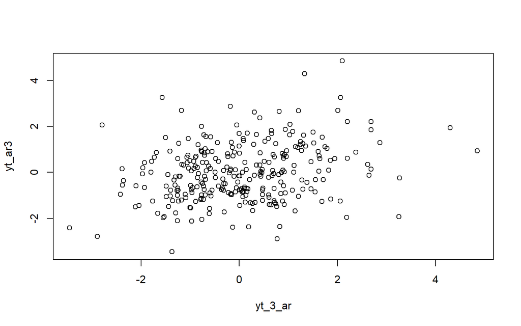

```r
plot(y=yt_ar3,x=yt_3_ar)
```

Berdasarkan scatterplot tersebut, terlihat bahwa terdapat hubungan positif yang lemah antara $Y_t$ dengan $Y_{t-3}$.

```r
cor(yt_ar3,yt_3_ar)
```

```
## [1] 0.2690422
```

Korelasi antara $Y_t$ dengan $Y_{t-3}$ dari hasil simulasi sedkit mendekati perhitungan teoritis yaitu

$$\rho_3=\phi_1\rho_{k-1}+\phi_2\rho_{k-2}=\phi_1\rho_2+\phi_2\rho_1=0.5\times0.5125+0.2\times0.625=0.38125$$

### Kesimpulan

Meskipun nilai autokorelasi empiris hingga lag ke-3 menunjukkan kedekatan dengan teori AR(2), pola PACF yang hanya menunjukkan signifikansi pada lag ke-1 mengindikasikan bahwa struktur korelasi data bangkitan lebih konsisten dengan model AR(1). Oleh karena itu, model AR(2) memiliki kecocokan kuantitatif, namun secara struktural model AR(1) mungkin lebih tepat untuk merepresentasikan dinamika data.

# ARMA(2,2)

Dalam kasus ini, akan dibangkitkan suatu data dengan model ARMA(2,2) sebanyak 300 data yang memiliki nilai $\phi_1 = 0.5$ dan $\phi_2 = 0.2$ serta $\theta_1 = 0.4$ dan $\theta_2 = 0.6$. Rumusan model tersebut adalah sebagai berikut:

$$Y_t =
0.5Y_{t-1}+0.2Y_{t-2}+e_t-0.4_{t-1}-0.6_{t-2}$$

```r
set.seed(1001)
phi1 = 0.5
phi2 = 0.2
theta1 = 0.4
theta2 = 0.6

y.arma=c(1:300)
for (i in 3:300){y.arma[i] = phi1*y.arma[i-1] + phi2*y.arma[i-2] +
                 wn[i] - theta1*wn[i-1] - theta2*wn[i-2]}
y.arma
```

```
##   [1]  1.00000000  2.00000000 -0.22744520 -2.03962030 -0.50883088  0.92094731
##   [7]  1.84201977  0.13179060 -0.87888466 -1.27004710  0.67380558  2.55245597
##  [13] -0.04620113  0.22265488  1.70759655  0.16059146  1.39577869 -1.11425402
##  [19] -2.32928291  0.32171036  0.21614910 -0.03879242  1.58538601  0.93002531
##  [25]  0.05309112 -1.09535863 -2.52396292 -0.17024203 -0.10861263 -1.51695037
##  [31]  0.66577913  0.99444268  0.11342664  2.58390650 -1.48969578  0.75755023
##  [37]  2.69069475 -0.53783219 -3.05035343 -0.39427258 -0.27011029  0.41644409
##  [43]  0.46677889 -0.77712700 -0.14497217  0.91472848 -1.55506348 -0.10666386
##  [49]  1.05711675  3.56964896 -0.65358392 -3.04474188 -1.94539063  1.06052284
##  [55]  1.01017438  0.64658249 -0.90497482  0.90506378  2.57965814 -0.73054878
##  [61] -1.81012121  0.49439804 -0.33645991 -0.68223917  0.91778920  1.84254330
##  [67]  1.55297466  0.26160824  0.48447796 -1.59589232 -2.60819057 -0.97301821
##  [73] -0.55206128 -1.94525379  1.61814020  0.16785078  0.48917849 -0.68711855
##  [79] -0.76860903  0.57602967  0.66453429  0.39227862  0.09714124 -0.52128684
##  [85] -0.54711773  0.92220547 -0.48908480  0.79884747 -0.59930861 -1.43698275
```

[output cut: 35 more lines]

Pembangkitan model ARMA(2,2) juga dapat dilakukan dengan menerapkan fungsi `arima.sim()`

```r
arma22 <- arima.sim(list(order=c(2,0,2), ar = c(0.5,0.2), ma = c(0.4,0.6)), n=300)
arma22
```

```
## Time Series:
## Start = 1
## End = 300
## Frequency = 1
##   [1] -0.464684383 -1.876677229 -2.693101514 -2.210238376 -2.149999435
##   [6] -1.275949819  1.425198610 -0.583845570  2.333384881  2.682782461
##  [11]  3.465996629  1.344904803  0.680375068 -1.178993032  0.008422658
##  [16] -0.232768110 -0.428626815 -0.486885653 -0.061480989 -1.592889884
##  [21] -0.853904876 -1.215888988  2.929794082  1.850926334  1.333858151
##  [26] -1.911340774 -1.508701562 -1.483137175  0.188489202 -0.854724529
##  [31]  0.702226516  2.166754242  2.132390040  1.598462489  1.250839128
##  [36]  0.234639590  0.324174894  0.713471212  2.280208836  4.180831710
##  [41]  5.028782038  6.040917865  4.188500152  2.344090036  0.476906256
##  [46] -0.908966398 -2.827332048 -1.167510749 -2.515448953 -0.179483116
##  [51] -1.971799313 -1.646358955 -1.985308247 -1.348157934 -0.726737982
```

[output cut: 49 more lines]

## Karakteristik ARMA(2,2)

### Plot Time Series

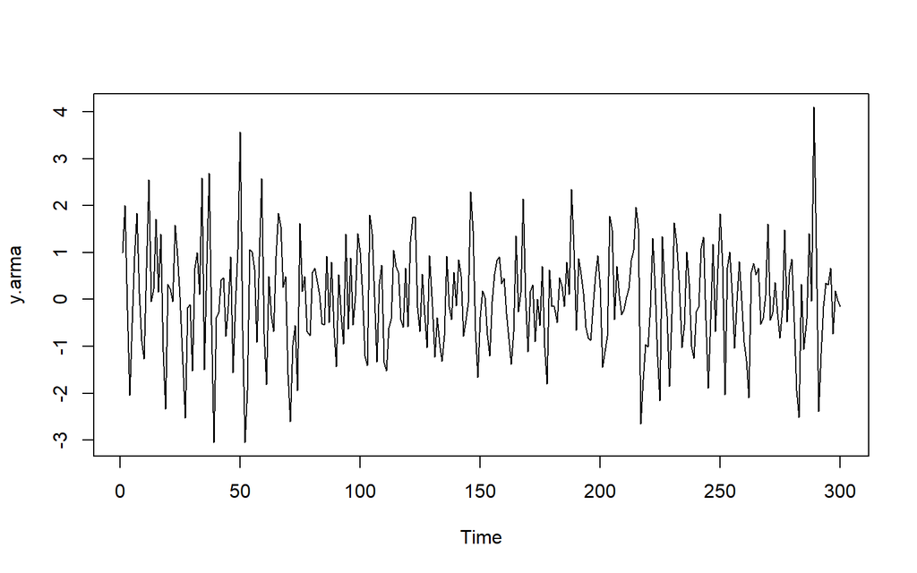

```r
ts.plot(y.arma)
```

Berdasarkan plot time series tersebut, terlihat bahwa model ARMA(2,2) cenderung stasioner dalam rataan.

### Plot ACF

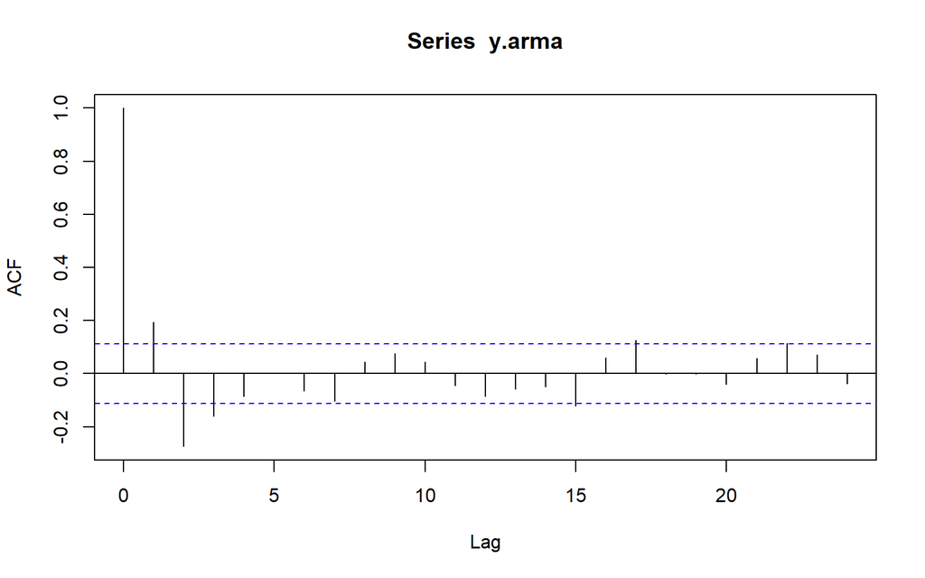

```r
acf(y.arma)
```

Berdasarkan plot ACF tersebut, terlihat bahwa model ARMA(2,2) hasil simulasi memiliki plot ACF yang *tails off*.

### Plot PACF

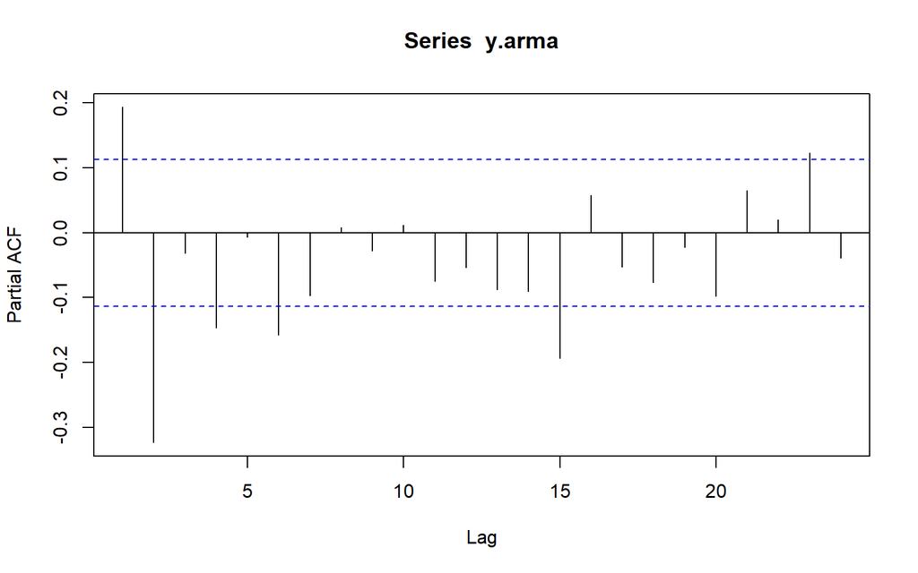

```r
pacf(y.arma)
```

Berdasarkan plot PACF tersebut, terlihat bahwa model ARMA(2,2) hasil simulasi memiliki plot PACF yang *tails off*.

### Plot EACF

```r
TSA::eacf(y.arma)
```

```
## AR/MA
##   0 1 2 3 4 5 6 7 8 9 10 11 12 13
## 0 x x x o o o o o o o o  o  o  o
## 1 x x o o o o o o o o o  o  o  o
## 2 o x o o o o o o o o o  o  o  o
## 3 x x x o o o x o o o o  o  o  o
## 4 o x x x o o x o o o o  o  o  o
## 5 o x x x o x x o o o o  o  o  o
## 6 x x x x x o x o o o o  o  o  o
## 7 o x o o x o x o o o o  o  o  o
```

### Scatterplot Antar Lag

#### Korelasi antara $Y_t$ dengan $Y_{t-1}$

```r
yt_arma <- y.arma[-1]
yt_arma
```

```
##   [1]  2.00000000 -0.22744520 -2.03962030 -0.50883088  0.92094731  1.84201977
##   [7]  0.13179060 -0.87888466 -1.27004710  0.67380558  2.55245597 -0.04620113
##  [13]  0.22265488  1.70759655  0.16059146  1.39577869 -1.11425402 -2.32928291
##  [19]  0.32171036  0.21614910 -0.03879242  1.58538601  0.93002531  0.05309112
##  [25] -1.09535863 -2.52396292 -0.17024203 -0.10861263 -1.51695037  0.66577913
##  [31]  0.99444268  0.11342664  2.58390650 -1.48969578  0.75755023  2.69069475
##  [37] -0.53783219 -3.05035343 -0.39427258 -0.27011029  0.41644409  0.46677889
##  [43] -0.77712700 -0.14497217  0.91472848 -1.55506348 -0.10666386  1.05711675
##  [49]  3.56964896 -0.65358392 -3.04474188 -1.94539063  1.06052284  1.01017438
##  [55]  0.64658249 -0.90497482  0.90506378  2.57965814 -0.73054878 -1.81012121
##  [61]  0.49439804 -0.33645991 -0.68223917  0.91778920  1.84254330  1.55297466
##  [67]  0.26160824  0.48447796 -1.59589232 -2.60819057 -0.97301821 -0.55206128
##  [73] -1.94525379  1.61814020  0.16785078  0.48917849 -0.68711855 -0.76860903
##  [79]  0.57602967  0.66453429  0.39227862  0.09714124 -0.52128684 -0.54711773
##  [85]  0.92220547 -0.48908480  0.79884747 -0.59930861 -1.43698275  0.53347881
```

[output cut: 35 more lines]

```r
yt_1_arma <- y.arma[-300]
yt_1_arma
```

```
##   [1]  1.00000000  2.00000000 -0.22744520 -2.03962030 -0.50883088  0.92094731
##   [7]  1.84201977  0.13179060 -0.87888466 -1.27004710  0.67380558  2.55245597
##  [13] -0.04620113  0.22265488  1.70759655  0.16059146  1.39577869 -1.11425402
##  [19] -2.32928291  0.32171036  0.21614910 -0.03879242  1.58538601  0.93002531
##  [25]  0.05309112 -1.09535863 -2.52396292 -0.17024203 -0.10861263 -1.51695037
##  [31]  0.66577913  0.99444268  0.11342664  2.58390650 -1.48969578  0.75755023
##  [37]  2.69069475 -0.53783219 -3.05035343 -0.39427258 -0.27011029  0.41644409
##  [43]  0.46677889 -0.77712700 -0.14497217  0.91472848 -1.55506348 -0.10666386
##  [49]  1.05711675  3.56964896 -0.65358392 -3.04474188 -1.94539063  1.06052284
##  [55]  1.01017438  0.64658249 -0.90497482  0.90506378  2.57965814 -0.73054878
##  [61] -1.81012121  0.49439804 -0.33645991 -0.68223917  0.91778920  1.84254330
##  [67]  1.55297466  0.26160824  0.48447796 -1.59589232 -2.60819057 -0.97301821
##  [73] -0.55206128 -1.94525379  1.61814020  0.16785078  0.48917849 -0.68711855
##  [79] -0.76860903  0.57602967  0.66453429  0.39227862  0.09714124 -0.52128684
##  [85] -0.54711773  0.92220547 -0.48908480  0.79884747 -0.59930861 -1.43698275
```

[output cut: 35 more lines]

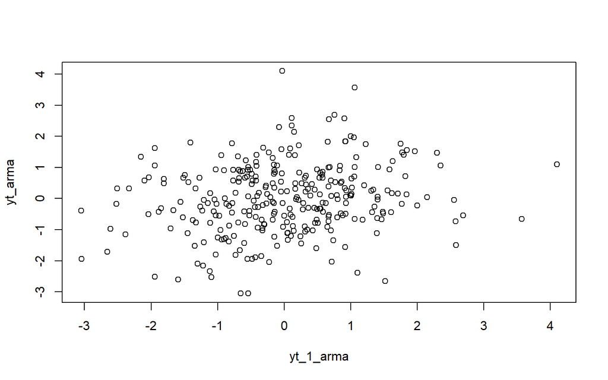

```r
plot(y=yt_arma,x=yt_1_arma)
```

Berdasarkan scatterplot tersebut, terlihat bahwa tidak terlalu ada hubungan yang jelas antara $Y_t$ dengan $Y_{t-1}$.

```r
cor(yt_arma,yt_1_arma)
```

```
## [1] 0.1935032
```

Korelasi antara $Y_t$ dengan $Y_{t-1}$ dari hasil simulasi jauh berbeda dengan teori, jika berdasarkan teori:

$$\rho_1 = \frac{(1 - \phi_2)\theta_1 + (\phi_1 - \phi_2)\theta_2 +
\phi_1(1 + \theta_1^2 + \theta_2^2)}
{(1 - \phi_2)(1 + \theta_1^2 + \theta_2^2) + 2(\phi_1 -
\phi_2)\theta_1\theta_2}
= \frac{(1 - 0.2)(0.4) + (0.5 - 0.2)(0.6) + 0.5(1 + 0.4^2 + 0.6^2)}
{(1 - 0.2)(1 + 0.4^2 + 0.6^2) + 2(0.5 - 0.2)(0.4)(0.6)}
= \frac{1.26}{1.36} \approx 0.926$$
#### Korelasi antara $Y_t$ dengan $Y_{t-2}$

```r
yt_arma <- y.arma[-c(1,2)]
yt_arma
```

```
##   [1] -0.22744520 -2.03962030 -0.50883088  0.92094731  1.84201977  0.13179060
##   [7] -0.87888466 -1.27004710  0.67380558  2.55245597 -0.04620113  0.22265488
##  [13]  1.70759655  0.16059146  1.39577869 -1.11425402 -2.32928291  0.32171036
##  [19]  0.21614910 -0.03879242  1.58538601  0.93002531  0.05309112 -1.09535863
##  [25] -2.52396292 -0.17024203 -0.10861263 -1.51695037  0.66577913  0.99444268
##  [31]  0.11342664  2.58390650 -1.48969578  0.75755023  2.69069475 -0.53783219
##  [37] -3.05035343 -0.39427258 -0.27011029  0.41644409  0.46677889 -0.77712700
##  [43] -0.14497217  0.91472848 -1.55506348 -0.10666386  1.05711675  3.56964896
##  [49] -0.65358392 -3.04474188 -1.94539063  1.06052284  1.01017438  0.64658249
##  [55] -0.90497482  0.90506378  2.57965814 -0.73054878 -1.81012121  0.49439804
##  [61] -0.33645991 -0.68223917  0.91778920  1.84254330  1.55297466  0.26160824
##  [67]  0.48447796 -1.59589232 -2.60819057 -0.97301821 -0.55206128 -1.94525379
##  [73]  1.61814020  0.16785078  0.48917849 -0.68711855 -0.76860903  0.57602967
##  [79]  0.66453429  0.39227862  0.09714124 -0.52128684 -0.54711773  0.92220547
##  [85] -0.48908480  0.79884747 -0.59930861 -1.43698275  0.53347881 -0.32779652
```

[output cut: 35 more lines]

```r
yt_2_arma <- y.arma[-c(299,300)]
yt_2_arma
```

```
##   [1]  1.00000000  2.00000000 -0.22744520 -2.03962030 -0.50883088  0.92094731
##   [7]  1.84201977  0.13179060 -0.87888466 -1.27004710  0.67380558  2.55245597
##  [13] -0.04620113  0.22265488  1.70759655  0.16059146  1.39577869 -1.11425402
##  [19] -2.32928291  0.32171036  0.21614910 -0.03879242  1.58538601  0.93002531
##  [25]  0.05309112 -1.09535863 -2.52396292 -0.17024203 -0.10861263 -1.51695037
##  [31]  0.66577913  0.99444268  0.11342664  2.58390650 -1.48969578  0.75755023
##  [37]  2.69069475 -0.53783219 -3.05035343 -0.39427258 -0.27011029  0.41644409
##  [43]  0.46677889 -0.77712700 -0.14497217  0.91472848 -1.55506348 -0.10666386
##  [49]  1.05711675  3.56964896 -0.65358392 -3.04474188 -1.94539063  1.06052284
##  [55]  1.01017438  0.64658249 -0.90497482  0.90506378  2.57965814 -0.73054878
##  [61] -1.81012121  0.49439804 -0.33645991 -0.68223917  0.91778920  1.84254330
##  [67]  1.55297466  0.26160824  0.48447796 -1.59589232 -2.60819057 -0.97301821
##  [73] -0.55206128 -1.94525379  1.61814020  0.16785078  0.48917849 -0.68711855
##  [79] -0.76860903  0.57602967  0.66453429  0.39227862  0.09714124 -0.52128684
##  [85] -0.54711773  0.92220547 -0.48908480  0.79884747 -0.59930861 -1.43698275
```

[output cut: 35 more lines]

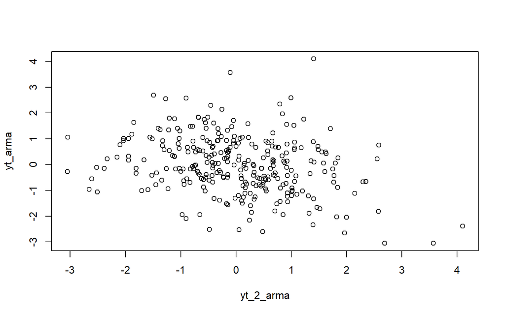

```r
plot(y=yt_arma,x=yt_2_arma)
```

Berdasarkan scatterplot tersebut, terlihat bahwa terdapat hubungan negatif lemah antara $Y_t$ dengan $Y_{t-2}$.

```r
cor(yt_arma,yt_2_arma)
```

```
## [1] -0.2756555
```

Nilai korelasi antara $Y_t$ dengan $Y_{t-2}$ dari hasil simulasi jauh berbeda dengan teori, jika berdasarkan teori:

$$\rho_2 = \frac{(\phi_1 + \theta_1\theta_2)(1 - \phi_2) + (\phi_1^2 -
\phi_2)(1 + \theta_1^2 + \theta_2^2) + \theta_2(\theta_1 +
\phi_1\theta_2)}
{(1 - \phi_2)(1 + \theta_1^2 + \theta_2^2) + 2(\phi_1 -
\phi_2)\theta_1\theta_2}
= \frac{(0.5 + 0.4 \times 0.6)(0.8) + (0.5^2 - 0.2)(1 + 0.4^2 + 0.6^2) +
0.6(0.4 + 0.5 \times 0.6)}
{(1-0.2)(1 + 0.4^2 + 0.6^2) + 2(0.5 - 0.2)(0.4)(0.6)}
= \frac{1.088}{1.36} = 0.8$$
#### Korelasi antara $Y_t$ dengan $Y_{t-3}$

```r
yt_arma <- y.arma[-c(1,2,3)]
yt_arma
```

```
##   [1] -2.03962030 -0.50883088  0.92094731  1.84201977  0.13179060 -0.87888466
##   [7] -1.27004710  0.67380558  2.55245597 -0.04620113  0.22265488  1.70759655
##  [13]  0.16059146  1.39577869 -1.11425402 -2.32928291  0.32171036  0.21614910
##  [19] -0.03879242  1.58538601  0.93002531  0.05309112 -1.09535863 -2.52396292
##  [25] -0.17024203 -0.10861263 -1.51695037  0.66577913  0.99444268  0.11342664
##  [31]  2.58390650 -1.48969578  0.75755023  2.69069475 -0.53783219 -3.05035343
##  [37] -0.39427258 -0.27011029  0.41644409  0.46677889 -0.77712700 -0.14497217
##  [43]  0.91472848 -1.55506348 -0.10666386  1.05711675  3.56964896 -0.65358392
##  [49] -3.04474188 -1.94539063  1.06052284  1.01017438  0.64658249 -0.90497482
##  [55]  0.90506378  2.57965814 -0.73054878 -1.81012121  0.49439804 -0.33645991
##  [61] -0.68223917  0.91778920  1.84254330  1.55297466  0.26160824  0.48447796
##  [67] -1.59589232 -2.60819057 -0.97301821 -0.55206128 -1.94525379  1.61814020
##  [73]  0.16785078  0.48917849 -0.68711855 -0.76860903  0.57602967  0.66453429
##  [79]  0.39227862  0.09714124 -0.52128684 -0.54711773  0.92220547 -0.48908480
##  [85]  0.79884747 -0.59930861 -1.43698275  0.53347881 -0.32779652 -0.94472036
```

[output cut: 35 more lines]

```r
yt_3_arma <- y.arma[-c(298,299,300)]
yt_3_arma
```

```
##   [1]  1.00000000  2.00000000 -0.22744520 -2.03962030 -0.50883088  0.92094731
##   [7]  1.84201977  0.13179060 -0.87888466 -1.27004710  0.67380558  2.55245597
##  [13] -0.04620113  0.22265488  1.70759655  0.16059146  1.39577869 -1.11425402
##  [19] -2.32928291  0.32171036  0.21614910 -0.03879242  1.58538601  0.93002531
##  [25]  0.05309112 -1.09535863 -2.52396292 -0.17024203 -0.10861263 -1.51695037
##  [31]  0.66577913  0.99444268  0.11342664  2.58390650 -1.48969578  0.75755023
##  [37]  2.69069475 -0.53783219 -3.05035343 -0.39427258 -0.27011029  0.41644409
##  [43]  0.46677889 -0.77712700 -0.14497217  0.91472848 -1.55506348 -0.10666386
##  [49]  1.05711675  3.56964896 -0.65358392 -3.04474188 -1.94539063  1.06052284
##  [55]  1.01017438  0.64658249 -0.90497482  0.90506378  2.57965814 -0.73054878
##  [61] -1.81012121  0.49439804 -0.33645991 -0.68223917  0.91778920  1.84254330
##  [67]  1.55297466  0.26160824  0.48447796 -1.59589232 -2.60819057 -0.97301821
##  [73] -0.55206128 -1.94525379  1.61814020  0.16785078  0.48917849 -0.68711855
##  [79] -0.76860903  0.57602967  0.66453429  0.39227862  0.09714124 -0.52128684
##  [85] -0.54711773  0.92220547 -0.48908480  0.79884747 -0.59930861 -1.43698275
```

[output cut: 35 more lines]

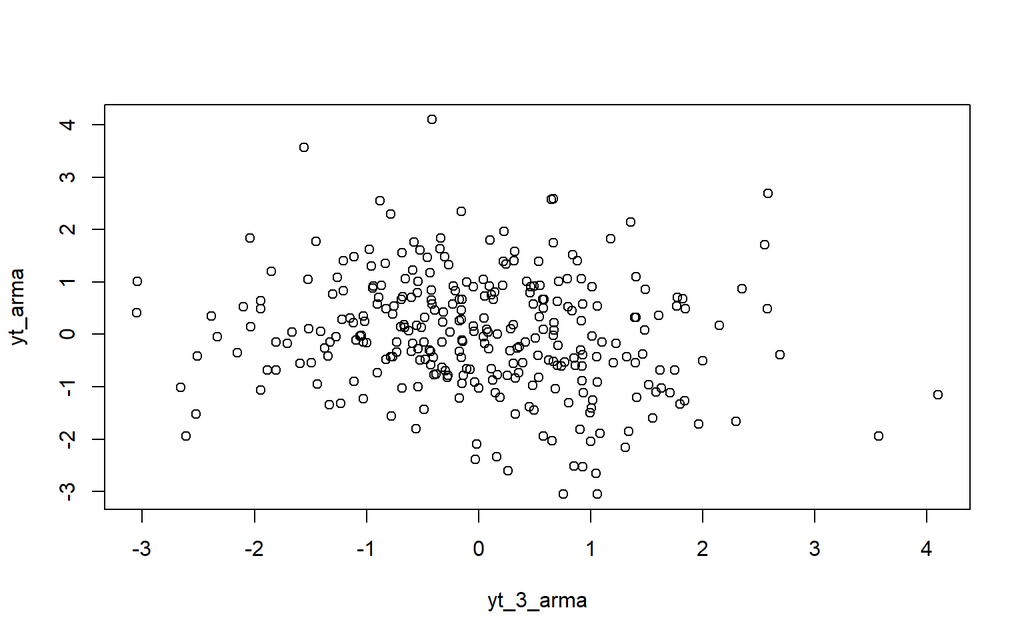

```r
plot(y=yt_arma,x=yt_3_arma)
```

Berdasarkan scatterplot tersebut, terlihat bahwa tidak ada hubungan yang jelas antara $Y_t$ dengan $Y_{t-3}$. Hal ini juga terbukti pada nilai korelasi yang rendah:

```r
cor(yt_arma,yt_3_arma)
```

```
## [1] -0.1605263
```

$$\rho_3 = \phi_1 \rho_2 + \phi_2 \rho_1
= (0.5)(0.8) + (0.2)(0.926)
= 0.5852$$